```python
import random
import numpy as np
import matplotlib.pyplot as plt

import sys
sys.path.append("..")
from solarbench import FormatMLDataset, load_datasets, get_dataloader, DatasetsInfo
import solarbench.evaluation as evaluation
from demo_helpers import display_sample, display_tensor_img
```

# Dataset meta information retrieval

The `DatasetsInfo` class allows you to retrieve the meta information for the datasets that you are interested in. You can query the information either by dataset names (`DatasetsInfo.by_name`) or by dataset features (`GetDatasetsInfo.by_features`).

### Obtaining metadata for all datasets

`DatasetsInfo.datasets` allows you to retrieve a pandas DataFrame containing metadata for every dataset in SolarBench.

```python
DatasetsInfo.datasets
```

|  | name | region | country | location | years_collected | data_types | img_res | time_res (minutes) | num_train | num_test |
| --- | --- | --- | --- | --- | --- | --- | --- | --- | --- | --- |
| 0 | UCSD-Folsom | NA | United States | [38.642, -121.148] | 2014-2016 | [sky_img, irrad, weather] | [64, 64] | 1 | 722320 | 42820 |
| 1 | SIPPMIF | OC | Australia | [-34.400309, 150.899807] | 2019 | [sky_img, pv] | [64, 64] | 1 | 1000 | 500 |
| 2 | SKIPPD | NA | United States | [37.427, -122.174] | 2017-2019 | [sky_img, pv] | [64, 64] | 1 | 349372 | 14003 |
| 3 | SRRL-BMS | NA | United States | [39.742, -105.18] | 2021-2024 | [sky_img, irrad, weather] | [64, 64] | 1 | 347121 | 20757 |
| 4 | COPDD | EU | France | [45.7742447, 2.96240064] | 2015-2023 | [sky_img, irrad, weather] | [64, 64] | [1, 2] | 973555 | 75247 |
| 5 | SIRTA | EU | France | [48.713, 2.208] | 2015-2022 | [sky_img, irrad, weather] | [64, 64] | [1, 2] | 1390161 | 78283 |
| 6 | EnerSHelF-StAugustin | EU | Germany | [50.779376, 7.182599] | 2020-2022 | [sky_img, irrad] | [64, 64] | 1 | 445598 | 24187 |
| 7 | EnerSHelF-Akwatia | AF | Ghana | [6.047167, -0.797028] | 2022 | [sky_img, irrad] | [64, 64] | 1 | 84717 | 5824 |
| 8 | EnerSHelF-Kologo | AF | Ghana | [10.737222, -1.077556] | 2022 | [sky_img, irrad] | [64, 64] | 1 | 87099 | 6053 |
| 9 | HK-PolyU | AS | Hong Kong | [22.335, 114.264] | 2023 | [sky_img, irrad, weather] | [64, 64] | 1 | 412027 | 20317 |
| 10 | UNottingham | EU | United Kingdom | [52.9529047, -1.1825815] | 2023 | [sky_img, irrad, weather] | [64, 64] | 1 | 59561 | 8676 |
| 11 | UQueensland | OC | Australia | [-27.55960330542919, 152.34060760751836] | 2020 | [sky_img, pv] | [64, 64] | 1 | 73619 | 3721 |

`DatasetsInfo.benchmarks` allows you to retrieve a pandas Dataframe containing information about the available benchmark datasets composed of multiple SolarBench datasets.

```python
DatasetsInfo.benchmarks
```

|  | name | datasets |
| --- | --- | --- |
| 0 | forecast-irradiance | [SRRL-BMS, UCSD-Folsom, SKIPPD, COPDD, SIRTA, ... |
| 1 | forecast-pv | [SKIPPD, SIPPMIF] |

### Query by dataset names

`DatasetsInfo.by_name` allows you to retrieve the information for a list of dataset names.

```python
# Retrieve the meta information of specific datasets
dataset_list = ['SRRL-BMS', 'SKIPPD']
DatasetsInfo.by_name(dataset_list)
```

|  | name | region | country | location | years_collected | data_types | img_res | time_res (minutes) | num_train | num_test |
| --- | --- | --- | --- | --- | --- | --- | --- | --- | --- | --- |
| 0 | SKIPPD | NA | United States | [37.427, -122.174] | 2017-2019 | [sky_img, pv] | [64, 64] | 1 | 349372 | 14003 |
| 1 | SRRL-BMS | NA | United States | [39.742, -105.18] | 2021-2024 | [sky_img, irrad, weather] | [64, 64] | 1 | 347121 | 20757 |

### Query by dataset features

`DatasetsInfo.by_features` allows you to retrieve the information by dataset features, e.g., the location of the data, the data types contained in the dataset, etc. A complete list of available query parameters is available in our full documentation.

```python
# Retrieve information for datasets that contain PV generation data
dataset_features = {'data_types':['pv']}
DatasetsInfo.by_features(dataset_features)
```

|  | name | region | country | location | years_collected | data_types | img_res | time_res (minutes) | num_train | num_test |
| --- | --- | --- | --- | --- | --- | --- | --- | --- | --- | --- |
| 1 | SIPPMIF | OC | Australia | [-34.400309, 150.899807] | 2019 | [sky_img, pv] | [64, 64] | 1 | 1000 | 500 |
| 2 | SKIPPD | NA | United States | [37.427, -122.174] | 2017-2019 | [sky_img, pv] | [64, 64] | 1 | 349372 | 14003 |
| 11 | UQueensland | OC | Australia | [-27.55960330542919, 152.34060760751836] | 2020 | [sky_img, pv] | [64, 64] | 1 | 73619 | 3721 |

```python
# Retrieve information for datasets that are collectioned in certain regions or countries,e.g., {'Country':['France']}
dataset_features = {'Region':['NA'], 'Country': ['United States']} # you are able to input multiple regions in the list
DatasetsInfo.by_features(dataset_features)
```

|  | name | region | country | location | years_collected | data_types | img_res | time_res (minutes) | num_train | num_test |
| --- | --- | --- | --- | --- | --- | --- | --- | --- | --- | --- |
| 0 | UCSD-Folsom | NA | United States | [38.642, -121.148] | 2014-2016 | [sky_img, irrad, weather] | [64, 64] | 1 | 722320 | 42820 |
| 1 | SKIPPD | NA | United States | [37.427, -122.174] | 2017-2019 | [sky_img, pv] | [64, 64] | 1 | 349372 | 14003 |
| 2 | SRRL-BMS | NA | United States | [39.742, -105.18] | 2021-2024 | [sky_img, irrad, weather] | [64, 64] | 1 | 347121 | 20757 |

```python
# Retrieve information for datasets that contain PV generation data and are collectioned in certain regions
dataset_features = {'Data_types':['pv'],'Region':['NA', 'OC']}
DatasetsInfo.by_features(dataset_features)
```

|  | name | region | country | location | years_collected | data_types | img_res | time_res (minutes) | num_train | num_test |
| --- | --- | --- | --- | --- | --- | --- | --- | --- | --- | --- |
| 0 | SIPPMIF | OC | Australia | [-34.400309, 150.899807] | 2019 | [sky_img, pv] | [64, 64] | 1 | 1000 | 500 |
| 1 | SKIPPD | NA | United States | [37.427, -122.174] | 2017-2019 | [sky_img, pv] | [64, 64] | 1 | 349372 | 14003 |
| 2 | UQueensland | OC | Australia | [-27.55960330542919, 152.34060760751836] | 2020 | [sky_img, pv] | [64, 64] | 1 | 73619 | 3721 |

### Fetching available/benchmark dataset names

For convenience, you can use `DatasetInfo.datasets_list` to obtain a Python list containing the names of the currently available datasets in SolarBench, and `DatasetInfo.benchmarks_list` for benchmark dataset names.

```python
print("Datasets:", DatasetsInfo.datasets_list)
print("Benchmarks:", DatasetsInfo.benchmarks_list)
```

```
Datasets: ['UCSD-Folsom', 'SIPPMIF', 'SKIPPD', 'SRRL-BMS', 'COPDD', 'SIRTA', 'EnerSHelF-StAugustin', 'EnerSHelF-Akwatia', 'EnerSHelF-Kologo', 'HK-PolyU', 'UNottingham', 'UQueensland']
Benchmarks: ['forecast-irradiance', 'forecast-pv']
```

# Dataset downloading

You can download or retrieve one or more datasets using `load_datasets`. If you would like to potentially speed up your download, you can set the `num_proc` keyword argument. Once datasets are downloaded once, they are cached locally in your system.

```python
dataset_list = ['SRRL-BMS', 'UCSD-Folsom', 'SIRTA']
datasets = load_datasets(dataset_list)
print(datasets)
```

```
Downloading dataset SRRL-BMS
Downloading dataset UCSD-Folsom
```

```
Downloading dataset SIRTA
```

```
<class 'solarbench.loading.LoaderContainer'>({
    'SRRL-BMS': DatasetDict({
        train: Dataset({
            features: ['image', 'time', 'ghi', 'dni', 'dhi', 'air_temp', 'relhum', 'press', 'windsp', 'winddir', 'max_windsp', 'precipitation'],
            num_rows: 347121
        })
        test: Dataset({
            features: ['image', 'time', 'ghi', 'dni', 'dhi', 'air_temp', 'relhum', 'press', 'windsp', 'winddir', 'max_windsp', 'precipitation'],
            num_rows: 20757
        })
    }),
    'UCSD-Folsom': DatasetDict({
        train: Dataset({
            features: ['image', 'time', 'ghi', 'dni', 'dhi', 'air_temp', 'relhum', 'press', 'windsp', 'winddir', 'max_windsp', 'precipitation'],
            num_rows: 722320
        })
        test: Dataset({
            features: ['image', 'time', 'ghi', 'dni', 'dhi', 'air_temp', 'relhum', 'press', 'windsp', 'winddir', 'max_windsp', 'precipitation'],
            num_rows: 42820
        })
    }),
    'SIRTA': DatasetDict({
        train: Dataset({
            features: ['image', 'time', 'ghi', 'ghi_std', 'ghi_min', 'ghi_max', 'dni', 'dni_std', 'dni_min', 'dni_max', 'dhi', 'dhi_std', 'dhi_min', 'dhi_max', 'lwd_max', 'air_temp', 'relhum', 'press'],
            num_rows: 1390161
        })
        test: Dataset({
            features: ['image', 'time', 'ghi', 'ghi_std', 'ghi_min', 'ghi_max', 'dni', 'dni_std', 'dni_min', 'dni_max', 'dhi', 'dhi_std', 'dhi_min', 'dhi_max', 'lwd_max', 'air_temp', 'relhum', 'press'],
            num_rows: 78283
        })
    }),
})
```

```python
# you can check individual datasets
# e.g., show the structure of the dataset
print(datasets['SIRTA'])
```

```
DatasetDict({
    train: Dataset({
        features: ['image', 'time', 'ghi', 'ghi_std', 'ghi_min', 'ghi_max', 'dni', 'dni_std', 'dni_min', 'dni_max', 'dhi', 'dhi_std', 'dhi_min', 'dhi_max', 'lwd_max', 'air_temp', 'relhum', 'press'],
        num_rows: 1390161
    })
    test: Dataset({
        features: ['image', 'time', 'ghi', 'ghi_std', 'ghi_min', 'ghi_max', 'dni', 'dni_std', 'dni_min', 'dni_max', 'dhi', 'dhi_std', 'dhi_min', 'dhi_max', 'lwd_max', 'air_temp', 'relhum', 'press'],
        num_rows: 78283
    })
})
```

```python
# e.g., query specifc samples
display(datasets['SRRL-BMS']['train'][0]['image'])
```

[output not shown]

# Dataset Formatting

Sky images can be used for different tasks, such as solar forecasting, cloud segmentation, cloud classification, and cloud motion prediction. Below is an example utilizing the `solar_forecast` formatter.

```python
formatted_datasets = FormatMLDataset.solar_forecast(datasets, forecast_span=2,       # time span from the first to the last forecasts
                                                    forecast_resolution=1,  # temporal resolution of the forecasts
                                                    lead_time=15,           # the time between the forecast submission deadline and the first forecast timestamp
                                                    history_length=15,      # time span from the first to the last input history
                                                    history_resolution=3,   # temporal resolution of the input history
                                                    sample_interval=2,      # the time interval between two consecutive samples
                                                    transform=None)
```

```
Formatting SRRL-BMS: split='train'.
```

```
Formatting SRRL-BMS: split='test'.
```

```
Formatting UCSD-Folsom: split='train'.
```

```
Formatting UCSD-Folsom: split='test'.
```

```
Formatting SIRTA: split='train'.
```

```
Formatting SIRTA: split='test'.
```

```python
# Create validation splits for the formatted datasets
formatted_datasets.split("random", 0.8)

# Combine the formatted datasets into one through concatenation
combined_dataset = formatted_datasets.combine("concat")
```

```python
print(f"Number of training samples: {len(combined_dataset['train'])}")
print(f"Number of validation samples: {len(combined_dataset['validation'])}")
print(f"Number of test samples: {len(combined_dataset['test'])}")
```

```
Number of training samples: 646206
Number of validation samples: 161549
Number of test samples: 46684
```

```
--------------------------------------------------
Sample from 2016-05-08 08:48:00+02:00 to 2016-05-08 09:03:00+02:00
Sample's keys and shapes:
                                      0
image_log    torch.Size([6, 3, 64, 64])
time_log                            [6]
target_log              torch.Size([6])
image_pred   torch.Size([3, 3, 64, 64])
time_pred                           [3]
target_pred             torch.Size([3])
Images (historical):
```

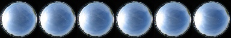

```
Images (future):
```

```
--------------------------------------------------
Sample from 2016-04-03 11:43:00+02:00 to 2016-04-03 11:58:00+02:00
Sample's keys and shapes:
                                      0
image_log    torch.Size([6, 3, 64, 64])
time_log                            [6]
target_log              torch.Size([6])
image_pred   torch.Size([3, 3, 64, 64])
time_pred                           [3]
target_pred             torch.Size([3])
Images (historical):
```

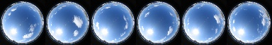

```
Images (future):
```

```
--------------------------------------------------
Sample from 2015-08-29 15:02:00-07:00 to 2015-08-29 15:17:00-07:00
Sample's keys and shapes:
                                      0
image_log    torch.Size([6, 3, 64, 64])
time_log                            [6]
target_log              torch.Size([6])
image_pred   torch.Size([3, 3, 64, 64])
time_pred                           [3]
target_pred             torch.Size([3])
Images (historical):
```

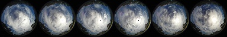

```
Images (future):
```

```
--------------------------------------------------
Sample from 2022-04-06 16:18:30-07:00 to 2022-04-06 16:33:30-07:00
Sample's keys and shapes:
                                      0
image_log    torch.Size([6, 3, 64, 64])
time_log                            [6]
target_log              torch.Size([6])
image_pred   torch.Size([3, 3, 64, 64])
time_pred                           [3]
target_pred             torch.Size([3])
Images (historical):
```

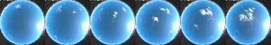

```
Images (future):
```

```
--------------------------------------------------
Sample from 2016-09-14 09:19:00+02:00 to 2016-09-14 09:34:00+02:00
Sample's keys and shapes:
                                      0
image_log    torch.Size([6, 3, 64, 64])
time_log                            [6]
target_log              torch.Size([6])
image_pred   torch.Size([3, 3, 64, 64])
time_pred                           [3]
target_pred             torch.Size([3])
Images (historical):
```

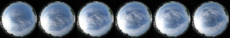

```
Images (future):
```

```python
for _ in range(5):
    idx = random.randint(0, len(combined_dataset['train']))
    display_sample(combined_dataset['train'][idx])
```

[output not shown]

# Using a DataLoader

## With a formatted dataset

```python
# Can set a batch_size parameter to use batched elements for training
formatted_dataloader = get_dataloader(combined_dataset['train'], batch_size=2)
```

```python
idx = 0
for example in formatted_dataloader:
    display_sample(example, False, False)
    idx += 1
    if idx > 5:
        break
```

```
DataLoader: Passing through field 'image_log'.
DataLoader: Passing through field 'target_log'.
DataLoader: Passing through field 'image_pred'.
DataLoader: Passing through field 'target_pred'.
--------------------------------------------------
Sample's keys and shapes:
                                         0
image_log    torch.Size([2, 6, 3, 64, 64])
time_log             torch.Size([2, 6, 7])
target_log              torch.Size([2, 6])
image_pred   torch.Size([2, 3, 3, 64, 64])
time_pred            torch.Size([2, 3, 7])
target_pred             torch.Size([2, 3])
--------------------------------------------------
Sample's keys and shapes:
                                         0
image_log    torch.Size([2, 6, 3, 64, 64])
time_log             torch.Size([2, 6, 7])
target_log              torch.Size([2, 6])
image_pred   torch.Size([2, 3, 3, 64, 64])
time_pred            torch.Size([2, 3, 7])
target_pred             torch.Size([2, 3])
--------------------------------------------------
Sample's keys and shapes:
                                         0
image_log    torch.Size([2, 6, 3, 64, 64])
time_log             torch.Size([2, 6, 7])
target_log              torch.Size([2, 6])
image_pred   torch.Size([2, 3, 3, 64, 64])
time_pred            torch.Size([2, 3, 7])
target_pred             torch.Size([2, 3])
--------------------------------------------------
Sample's keys and shapes:
                                         0
image_log    torch.Size([2, 6, 3, 64, 64])
time_log             torch.Size([2, 6, 7])
target_log              torch.Size([2, 6])
image_pred   torch.Size([2, 3, 3, 64, 64])
time_pred            torch.Size([2, 3, 7])
target_pred             torch.Size([2, 3])
--------------------------------------------------
Sample's keys and shapes:
                                         0
image_log    torch.Size([2, 6, 3, 64, 64])
time_log             torch.Size([2, 6, 7])
target_log              torch.Size([2, 6])
image_pred   torch.Size([2, 3, 3, 64, 64])
time_pred            torch.Size([2, 3, 7])
target_pred             torch.Size([2, 3])
--------------------------------------------------
Sample's keys and shapes:
                                         0
image_log    torch.Size([2, 6, 3, 64, 64])
time_log             torch.Size([2, 6, 7])
target_log              torch.Size([2, 6])
image_pred   torch.Size([2, 3, 3, 64, 64])
time_pred            torch.Size([2, 3, 7])
target_pred             torch.Size([2, 3])
```

# Evaluating your Model

Provided are various functions for evaluation of a model's performance.

These include:

- Mean Absolute Error (MAE)
- Root Mean Squared Error (RMSE)
- Mean Bias Error (MBE)
- Relative RMSE (RRMSE)
- Temporal Distortion Index (TDI)
- Temporal Distortion Mix (TDM)

See Barhmi et. al. (2024) (https://www.mdpi.com/2673-9941/4/1/5) for more details.

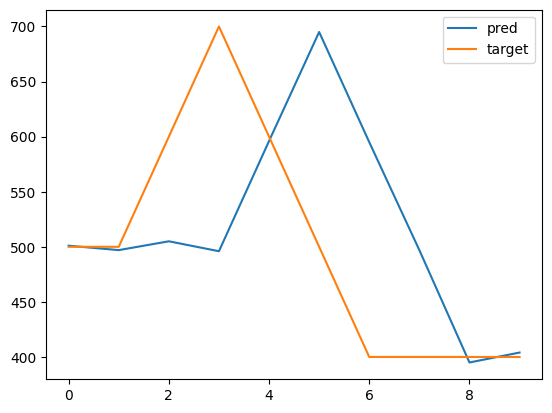

```python
# Generate some sample data
pred_ghi = np.array([random.randint(-5, 5) + pred for pred in [500, 500, 500, 500, 600, 700, 600, 500, 400, 400]])
target_ghi = np.array([500, 500, 600, 700, 600, 500, 400, 400, 400, 400])
plt.plot(pred_ghi, label='pred')
plt.plot(target_ghi, label='target')
plt.legend()
plt.show()
```

```python
# Evaluate with the various metrics

print(f"MAE: {evaluation.mae(target_ghi, pred_ghi):.2f}")

print(f"RMSE: {evaluation.rmse(target_ghi, pred_ghi):.2f}")

print(f"MBE: {evaluation.mbe(target_ghi, pred_ghi):.2f}")

print(f"RRMSE: {evaluation.rrmse(target_ghi, pred_ghi):.2f}")

print(f"TDI: {evaluation.tdi(target_ghi, pred_ghi):.2f}")

print(f"TDI (Advance): {evaluation.tdi_adv(target_ghi, pred_ghi):.2f}")

print(f"TDI (Late): {evaluation.tdi_late(target_ghi, pred_ghi):.2f}")

print(f"TDM: {evaluation.tdm(target_ghi, pred_ghi):.2f}")
```

```
MAE: 80.30
RMSE: 116.69
MBE: -18.10
RRMSE: 0.22
TDI: 0.28
TDI (Advance): 1.00
TDI (Late): 0.00
TDM: -1.00
```

# Loading a benchmark

```python
benchmark = load_datasets('forecast-pv', num_proc=10)
```

```
Loading benchmark 'forecast-pv' containing datasets: ['SKIPPD', 'SIPPMIF']
Downloading dataset SKIPPD
Downloading dataset SIPPMIF
```

```python
print(benchmark)
```

```
<class 'solarbench.loading.LoaderContainer'>({
    'SKIPPD': DatasetDict({
        train: Dataset({
            features: ['image', 'time', 'pv'],
            num_rows: 349372
        })
        test: Dataset({
            features: ['image', 'time', 'pv'],
            num_rows: 14003
        })
    }),
    'SIPPMIF': DatasetDict({
        train: Dataset({
            features: ['image', 'time', 'pv'],
            num_rows: 1000
        })
        test: Dataset({
            features: ['image', 'time', 'pv'],
            num_rows: 500
        })
    }),
})
```

# Putting it all together

The following is an example combining the above steps into one cell.

```python
datasets = ["SIPPMIF", "SKIPPD"]
datasets_container = load_datasets(datasets, num_proc=10)
formatted_datasets = FormatMLDataset.solar_estimation(datasets_container, target_label="pv", normalization="max")
formatted_datasets.split("random", 0.8)
combined_dataset = formatted_datasets.combine("concat")

train_dataloader = get_dataloader(combined_dataset['train'])
validation_dataloader = get_dataloader(combined_dataset['validation'])
test_dataloader = get_dataloader(combined_dataset['test'])
```

```
Downloading dataset SIPPMIF
Downloading dataset SKIPPD
Formatting SIPPMIF: split='train'.
Formatting SIPPMIF: split='test'.
Formatting SKIPPD: split='train'.
Formatting SKIPPD: split='test'.
```

```python
# Print out a couple samples from each loader
def print_non_image(sample):
    labels = {key: value for key, value in sample.items() if key != 'image'}
    print(f"Labels: {labels}")

itrain = iter(train_dataloader)
ivalid = iter(validation_dataloader)
itest = iter(test_dataloader)
for i in range(605):
    train_sample = next(itrain)
    validation_sample = next(ivalid)
    test_sample = next(itest)

    if i > 603: # Get samples from both datasets
        print("Train Sample")
        print("Prediction target:", train_sample['target'])
        print_non_image(train_sample)
        display_tensor_img(train_sample['image'][0])

        print("Validation Sample")
        print("Prediction target:", validation_sample['target'])
        print_non_image(validation_sample)
        display_tensor_img(validation_sample['image'][0])

        print("Test Sample")
        print("Prediction target:", test_sample['target'])
        print_non_image(test_sample)
        display_tensor_img(test_sample['image'][0])
```

[output not shown]

```
DataLoader: Passing through field 'target'.
DataLoader: Converting field 'image' to tensor.
DataLoader: Passing through field 'target'.
DataLoader: Converting field 'image' to tensor.
DataLoader: Passing through field 'target'.
DataLoader: Converting field 'image' to tensor.
Train Sample
Prediction target: tensor([0.6140], dtype=torch.float64)
Labels: {'target': tensor([0.6140], dtype=torch.float64), 'time': [tensor([2019]), tensor([9]), tensor([10]), tensor([14]), tensor([26]), tensor([0]), tensor([36000.], dtype=torch.float64)]}
```

```
Validation Sample
Prediction target: tensor([0.5222], dtype=torch.float64)
Labels: {'target': tensor([0.5222], dtype=torch.float64), 'time': [tensor([2019]), tensor([8]), tensor([15]), tensor([17]), tensor([25]), tensor([40]), tensor([-25200.], dtype=torch.float64)]}
```

```
Test Sample
Prediction target: tensor([0.1084], dtype=torch.float64)
Labels: {'target': tensor([0.1084], dtype=torch.float64), 'time': [tensor([2017]), tensor([6]), tensor([24]), tensor([9]), tensor([27]), tensor([40]), tensor([-25200.], dtype=torch.float64)]}
```